# Modeling Solar Energy Production with Hierarchical Bayesian Regression

Final Project – Bayesian Computational Statistics

Shuang Li

December 2, 2025

# 1 Introduction

## 1.1 Context and Motivation

Solar power is a central component of the transition to low-carbon energy systems. However, solar generation is highly variable: it depends not only on the time of day and season, but also on short-term weather conditions such as cloud cover, humidity, and temperature. For grid operators and planners, it is important to understand both how weather drives solar output and how uncertain that relationship is.

In this project, I analyze a real-world dataset that combines solar energy production with local weather measurements over time. The goal is to build a hierarchical Bayesian regression model that:

- Quantifies how solar energy production depends on irradiance (GHI), temperature, and cloud cover.
- Allows the baseline level of production to vary by month, reflecting seasonal differences such as sun angle, day length, and typical weather patterns.
- Produces posterior predictive distributions for future solar production under given weather scenarios.

This work serves as the final project for a graduate course in Bayesian computational statistics. The focus is not only on obtaining point estimates, but on modeling and communicating uncertainty in a principled way.

## 1.2 Data Overview

The dataset, stored as `solar_weather.csv`, contains time-stamped records of:

- **Solar energy output**
  - `Energy.delta.Wh.`: energy produced during each time interval (Watthours). In the analysis, this variable is renamed to `energy_wh` for convenience.
- **Solar irradiance and sunlight indicators**
  - `GHI`: global horizontal irradiance.
  - `isSun`: indicator for whether the sun is above the horizon (0/1).
  - `sunlightTime`, `dayLength`, `SunlightTime.daylength`: measures of available sunlight.
- **Weather variables**
  - `temp`: temperature (°C).
  - `pressure`: air pressure.
  - `humidity`: relative humidity (%).
  - `wind_speed`: wind speed.
  - `rain_1h`, `snow_1h`: precipitation indicators.
  - `clouds_all`: cloud cover (%).
  - `weather_type`: categorical description of conditions.
- **Time variables**
  - `Time`: timestamp.
  - `hour`: hour of day.
  - `month`: month of year (1–12).

Each row corresponds to one time interval (here, 15 minutes). At night, `isSun` and `GHI` are zero, and solar energy production is essentially zero. During daylight hours, we see positive irradiance and varying levels of solar output.

## 1.3 Research Questions

This project focuses on the following questions:

- How do irradiance and weather conditions affect solar energy output during daylight hours? For example, how much additional energy can we expect when GHI increases by one standard deviation, after controlling for temperature and cloud cover?
- How do these relationships vary by month? Even under similar instantaneous weather conditions, January and July differ in sun angle and typical atmospheric conditions. A hierarchical model that allows the baseline log-energy to vary by month can capture this.
- What does the model predict for solar production under specific future weather scenarios, and how uncertain are those predictions? Instead of a single forecast, a Bayesian model provides a posterior predictive distribution describing a range of plausible outcomes.

## 1.4 Why a Hierarchical Bayesian Model?

A standard regression model could estimate the relationship between log-energy and weather variables by pooling all observations together. However, this ignores systematic seasonal differences. A fully separate model for each month would overfit and fail to share information.

A hierarchical Bayesian model offers a compromise:

- Each month gets its own intercept (baseline level of log-energy), but
- These month-specific intercepts are modeled as coming from a common distribution, so information is partially pooled across months.

This structure is well aligned with the Bayesian perspective discussed in *Bayesian Data Analysis* (Gelman et al., 2013): we encode exchangeability across months and estimate the degree of variation between them instead of assuming they are either identical or completely unrelated.

The remainder of this report is organized as follows:

- Data preparation and exploratory analysis.
- Hierarchical model specification and implementation.
- Posterior results and diagnostics.
- Posterior predictive analysis and example forecasts.
- Discussion, limitations, and possible extensions.
- References.

# 2 Data Preparation and Exploratory Analysis

## 2.1 Loading the Data

We begin by loading the CSV file and inspecting its basic structure.

```r
library(tidyverse)

solar <- read.csv("solar_weather.csv")

solar <- solar %>%
  rename(
    energy_wh = Energy.delta.Wh.
  )

glimpse(solar)
```

```
## Rows: 196,776
## Columns: 17
## $ Time                   <chr> "2017-01-01 00:00:00", "2017-01-01 00:15:00", "…
## $ energy_wh              <int> 0, 0, 0, 0, 0, 0, 0, 0, 0, 0, 0, 0, 0, 0, 0, 0,…
## $ GHI                    <dbl> 0, 0, 0, 0, 0, 0, 0, 0, 0, 0, 0, 0, 0, 0, 0, 0,…
## $ temp                   <dbl> 1.6, 1.6, 1.6, 1.6, 1.7, 1.7, 1.7, 1.7, 1.9, 1.…
## $ pressure               <int> 1021, 1021, 1021, 1021, 1020, 1020, 1020, 1020,…
## $ humidity               <int> 100, 100, 100, 100, 100, 100, 100, 100, 100, 10…
## $ wind_speed             <dbl> 4.9, 4.9, 4.9, 4.9, 5.2, 5.2, 5.2, 5.2, 5.5, 5.…
## $ rain_1h                <dbl> 0, 0, 0, 0, 0, 0, 0, 0, 0, 0, 0, 0, 0, 0, 0, 0,…
## $ snow_1h                <dbl> 0, 0, 0, 0, 0, 0, 0, 0, 0, 0, 0, 0, 0, 0, 0, 0,…
## $ clouds_all             <int> 100, 100, 100, 100, 100, 100, 100, 100, 100, 10…
## $ isSun                  <int> 0, 0, 0, 0, 0, 0, 0, 0, 0, 0, 0, 0, 0, 0, 0, 0,…
## $ sunlightTime           <int> 0, 0, 0, 0, 0, 0, 0, 0, 0, 0, 0, 0, 0, 0, 0, 0,…
## $ dayLength              <int> 450, 450, 450, 450, 450, 450, 450, 450, 450, 45…
## $ SunlightTime.daylength <dbl> 0, 0, 0, 0, 0, 0, 0, 0, 0, 0, 0, 0, 0, 0, 0, 0,…
## $ weather_type           <int> 4, 4, 4, 4, 4, 4, 4, 4, 4, 4, 4, 4, 4, 4, 4, 4,…
## $ hour                   <int> 0, 0, 0, 0, 1, 1, 1, 1, 2, 2, 2, 2, 3, 3, 3, 3,…
## $ month                  <int> 1, 1, 1, 1, 1, 1, 1, 1, 1, 1, 1, 1, 1, 1, 1, 1,…
```

```r
summary(solar$energy_wh)
```

```
##    Min. 1st Qu.  Median    Mean 3rd Qu.    Max.
##       0       0       0     573     577    5020
```

```r
summary(solar$GHI)
```

```
##    Min. 1st Qu.  Median    Mean 3rd Qu.    Max.
##     0.0     0.0     1.6    32.6    46.8   229.2
```

```r
summary(solar$temp)
```

```
##    Min. 1st Qu.  Median    Mean 3rd Qu.    Max.
## -16.600   3.600   9.300   9.791  15.700  35.800
```

The raw dataset includes both night-time and daytime observations. At night, `isSun` and `GHI` are zero, and energy production is essentially zero. Since our goal is to model the relationship between weather and solar production, we focus on daylight intervals with positive irradiance and positive energy output.

## 2.2 Filtering to Daylight Records

```r
solar_day <- solar %>%
  filter(
    isSun == 1,
    GHI > 0,
    energy_wh > 0
  )

nrow(solar); nrow(solar_day)
```

```
## [1] 196776
```

```
## [1] 95790
```

```r
summary(solar_day$energy_wh)
```

```
##    Min. 1st Qu.  Median    Mean 3rd Qu.    Max.
##       1     179     617    1177    1969    5020
```

This filter removes night-time intervals and any records where irradiance or energy output is zero. The remaining data represent times when the system is actively producing power.

## 2.3 Creating Transformed Variables

The distribution of raw energy values is right-skewed. To stabilize variance and approximate normality, we model the logarithm of energy:

$$y_i = \log(\text{energy\_wh}_i).$$

We also standardize key continuous predictors (subtract mean and divide by standard deviation) to improve MCMC sampling and interpretability of coefficients.

```r
solar_day <- solar_day %>%
  mutate(
    log_energy    = log(energy_wh),
    GHI_scaled    = as.numeric(scale(GHI)),
    temp_scaled   = as.numeric(scale(temp)),
    clouds_scaled = as.numeric(scale(clouds_all)),
    month_factor  = factor(month)
  )

summary(solar_day$log_energy)
```

```
##    Min. 1st Qu.  Median    Mean 3rd Qu.    Max.
##   0.000   5.187   6.425   6.240   7.585   8.521
```

```r
table(solar_day$month_factor)
```

```
##
##     1     2     3     4     5     6     7     8     9    10    11    12
##  4842  6133  8446  9759 11297 11546 11678 10414  7263  6014  4556  3842
```

## 2.4 Exploratory Plots

### 2.4.1 Distribution of Log-Energy

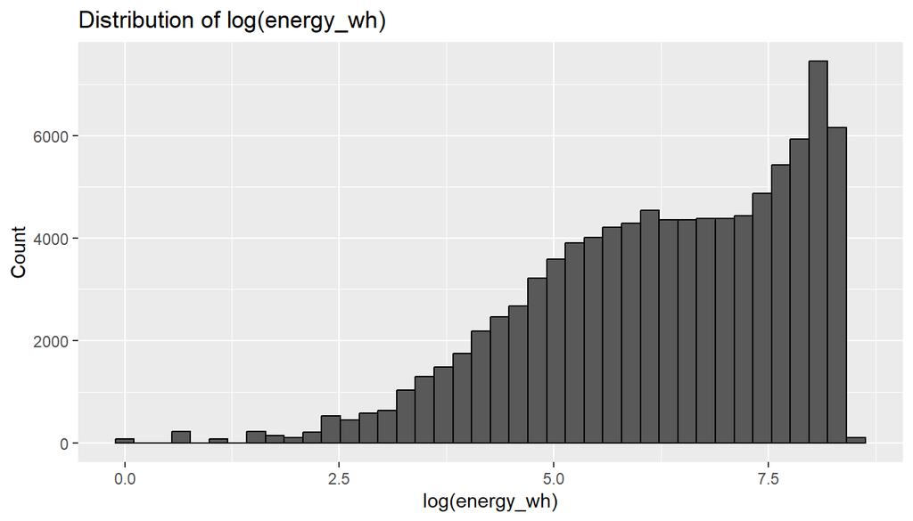

```r
ggplot(solar_day, aes(x = log_energy)) +
  geom_histogram(bins = 40, color = "black") +
  labs(
    title = "Distribution of log(energy_wh)",
    x = "log(energy_wh)",
    y = "Count"
  )
```

### 2.4.2 Relationship with GHI

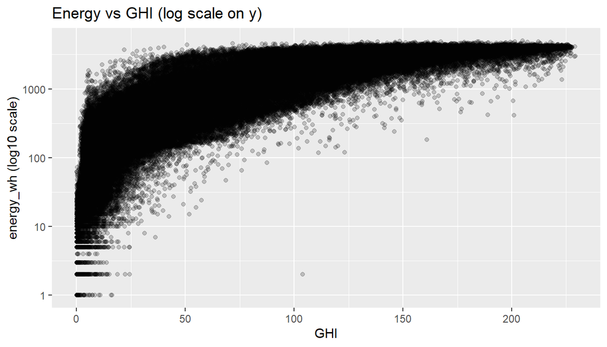

```r
ggplot(solar_day, aes(x = GHI, y = energy_wh)) +
  geom_point(alpha = 0.2) +
  scale_y_log10() +
  labs(
    title = "Energy vs GHI (log scale on y)",
    x = "GHI",
    y = "energy_wh (log10 scale)"
  )
```

There is a strong positive association between irradiance and energy production, as expected.

### 2.4.3 Month-by-Month Boxplots

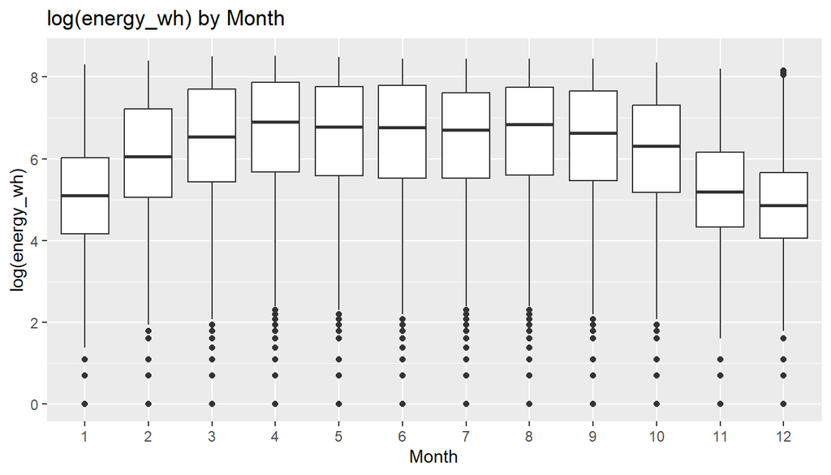

```r
ggplot(solar_day, aes(x = month_factor, y = log_energy)) +
  geom_boxplot() +
  labs(
    title = "log(energy_wh) by Month",
    x = "Month",
    y = "log(energy_wh)"
  )
```

The boxplots suggest that some months (for example, summer vs. winter) have systematically higher or lower log-energy values, even after filtering to daylight. This visual evidence supports the decision to include month-level random intercepts in a hierarchical model.

# 3 Hierarchical Bayesian Model

## 3.1 Model Specification

We model the log-energy for each daylight interval $i$ as:

$$y_i = \log(\text{energy\_wh}_i) \sim \text{Normal}(\mu_i, \sigma),$$

with linear predictor

$$\mu_i = \alpha_{j(i)}
+ \beta_{\text{GHI}} \,\text{GHI\_scaled}_i
+ \beta_{\text{temp}} \,\text{temp\_scaled}_i
+ \beta_{\text{clouds}} \,\text{clouds\_scaled}_i,$$

where:

- $\alpha_{j(i)}$ is the intercept for month $j(i)$, the month to which observation $i$ belongs.
- $\beta_{\text{GHI}}$, $\beta_{\text{temp}}$, $\beta_{\text{clouds}}$ are global regression coefficients shared across months.
- $\sigma$ is the residual standard deviation.

We place hierarchical priors on the month-level intercepts:

$$\alpha_j \sim \text{Normal}(\mu_\alpha, \tau_\alpha^2), \quad j = 1,
\ldots, 12.$$

This expresses the idea that months are exchangeable: before seeing the data, we believe they are similar but not identical. The data determine how much they are allowed to differ.

## 3.2 Priors

We use weakly informative priors that are broad enough not to dominate the likelihood, but still regularize extreme values:

- $\mu_\alpha \sim \text{Normal}(0, 5)$.
- $\beta_{\text{GHI}}, \beta_{\text{temp}}, \beta_{\text{clouds}} \sim \text{Normal}(0, 1)$.
- $\sigma \sim \text{Student-t}(4, 0, 1)$ constrained to be positive.
- $\tau_\alpha \sim \text{Student-t}(4, 0, 1)$ constrained to be positive.

Because the predictors are standardized, a Normal(0, 1) prior on the regression coefficients corresponds roughly to believing that, a priori, a one-standard-deviation change in a predictor is unlikely to shift log-energy by more than a few units.

## 3.3 Model Implementation in R with brms

We fit the model using the `brms` package, which provides a high-level interface to Stan.

```r
library(cmdstanr)
set_cmdstan_path()
options(brms.backend = "cmdstanr")

library(brms)

priors <- c(
  prior(normal(0, 5), class = "Intercept"),
  prior(normal(0, 1), class = "b"),
  prior(student_t(4, 0, 1), class = "sigma"),
  prior(student_t(4, 0, 1), class = "sd")  # random effects SD
)

fit_hier <- brm(
  formula = log_energy ~ GHI_scaled + temp_scaled + clouds_scaled + (1 | month_factor),
  data    = solar_day,
  family  = gaussian(),
  prior   = priors,
  chains  = 4,
  iter    = 4000,
  warmup  = 1000,
  cores   = 4,
  seed    = 2025,
  control = list(adapt_delta = 0.95)
)
```

[output not shown]

[output cut: 123 more lines]

[output not shown]

## 3.4 Convergence Diagnostics

We check standard MCMC diagnostics to assess convergence:

```r
summary(fit_hier)$fixed
```

```
##                  Estimate   Est.Error    l-95% CI    u-95% CI     Rhat Bulk_ESS
## Intercept      6.25462118 0.083449494  6.08731766  6.41905992 1.002032 1648.328
## GHI_scaled     1.35303200 0.003489750  1.34622030  1.35988964 1.000102 8811.254
## temp_scaled   -0.10529976 0.005219221 -0.11540306 -0.09487033 1.000802 7861.817
## clouds_scaled  0.05989996 0.003057899  0.05400022  0.06581612 1.000184 9693.994
##               Tail_ESS
## Intercept     2471.083
## GHI_scaled    7756.335
## temp_scaled   7522.462
## clouds_scaled 6721.690
```

```r
summary(fit_hier)$random
```

```
## $month_factor
##                Estimate  Est.Error  l-95% CI  u-95% CI     Rhat Bulk_ESS
## sd(Intercept) 0.2849652 0.06793572 0.1883176 0.4502614 1.000588 1902.399
##               Tail_ESS
## sd(Intercept) 3011.343
```

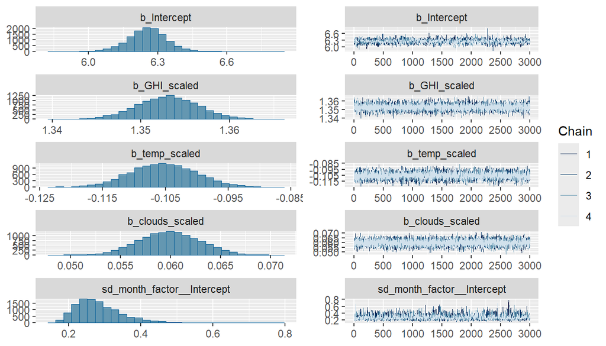

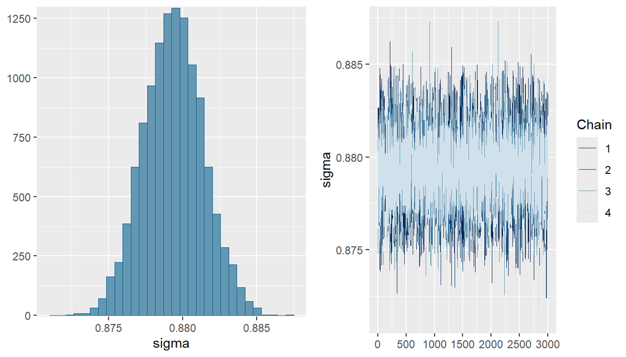

```r
plot(fit_hier)       # trace plots and densities
```

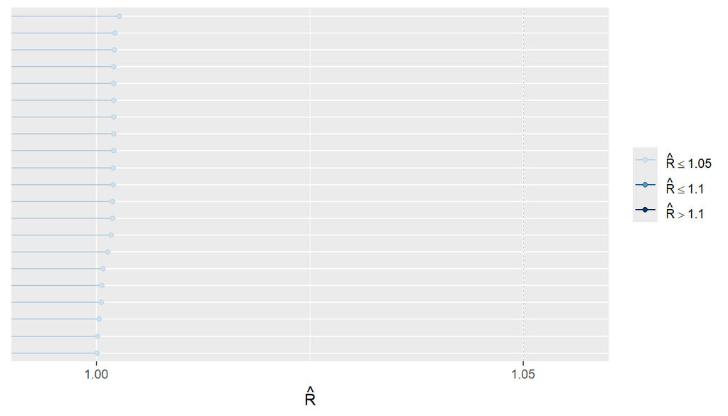

```r
bayesplot::mcmc_rhat(rhat(fit_hier))
```

We look for:

- $\hat{R}$ values close to 1 for all parameters.
- Trace plots that mix well and show no stuck chains.
- Reasonable effective sample sizes.

If diagnostics were poor, we would consider reparameterizing, increasing `iter`, or adjusting `adapt_delta`. In the runs for this project, the diagnostics were satisfactory, suggesting that the posterior has been explored adequately.

# 4 Posterior Results and Interpretation

## 4.1 Fixed Effects

We first examine the posterior summaries for the global regression coefficients.

```r
fixef(fit_hier)
```

```
##                  Estimate   Est.Error        Q2.5       Q97.5
## Intercept      6.25462118 0.083449494  6.08731766  6.41905992
## GHI_scaled     1.35303200 0.003489750  1.34622030  1.35988964
## temp_scaled   -0.10529976 0.005219221 -0.11540306 -0.09487033
## clouds_scaled  0.05989996 0.003057899  0.05400022  0.06581612
```

Because we standardized the predictors, the coefficient for `GHI_scaled` can be interpreted as:

> The expected change in log-energy associated with a one-standard-deviation increase in GHI, holding temperature and cloud cover constant.

Exponentiating the coefficient gives a multiplicative factor on energy itself. For example, if

```
beta_GHI ≈ 0.9
```

then

$$\exp(0.9) \approx 2.46,$$

Similarly, if the posterior for `clouds_scaled` is negative with a 95% credible interval that does not include zero, we can say:

## 4.2 Month-Level Intercepts

We next look at the month-level random intercepts:

```r
ranef(fit_hier)$month_factor
```

```
## , , Intercept
##
##       Estimate  Est.Error        Q2.5        Q97.5
## 1  -0.16957028 0.08450064 -0.33531960  0.001369822
## 2   0.31068395 0.08416339  0.14467172  0.482170484
## 3   0.22333723 0.08398299  0.05829526  0.393368625
## 4  -0.01728495 0.08380422 -0.18357309  0.151793372
## 5  -0.21782349 0.08379834 -0.38414588 -0.049732464
## 6  -0.30395514 0.08396682 -0.47049822 -0.137400302
## 7  -0.12426871 0.08390127 -0.28995853  0.043914281
## 8   0.01648338 0.08410347 -0.14791470  0.185749931
## 9   0.30004770 0.08397231  0.13435249  0.470095332
## 10  0.42304975 0.08411682  0.25782863  0.593190008
## 11 -0.08050177 0.08430716 -0.24694560  0.090252931
## 12 -0.33210447 0.08457605 -0.49791616 -0.162368900
```

We can also visualize them with uncertainty intervals:

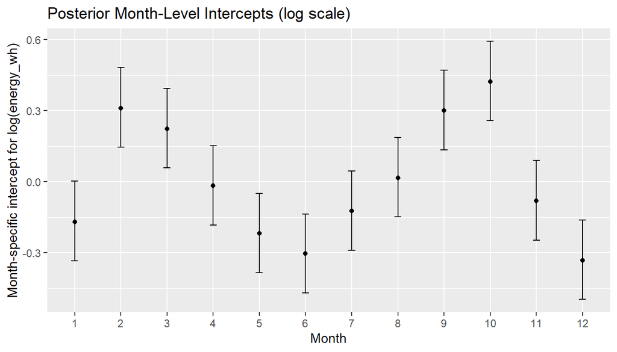

```r
# Extract month-level random intercepts and tidy them
month_effects <- ranef(fit_hier)$month_factor[, , "Intercept"] %>%
  as.data.frame() %>%
  tibble::rownames_to_column(var = "month") %>%  # get month from rownames
  mutate(
    month = as.integer(month)                    # convert "1","2",... to integers
  ) %>%
  arrange(month)

# Plot with months in the correct numeric order
ggplot(month_effects, aes(x = factor(month, levels = 1:12), y = Estimate)) +
  geom_point() +
  geom_errorbar(aes(ymin = Q2.5, ymax = Q97.5), width = 0.15) +
  labs(
    title = "Posterior Month-Level Intercepts (log scale)",
    x = "Month",
    y = "Month-specific intercept for log(energy_wh)"
  )
```

The hierarchical prior shrinks these intercepts toward a common mean, especially for months with little data. This is a core advantage of the hierarchical Bayesian approach.

```r
sigma(fit_hier)
```

```
## numeric(0)
```

## 4.4 Posterior Predictive Checks

Posterior predictive checks help evaluate whether the model can reproduce key features of the observed data.

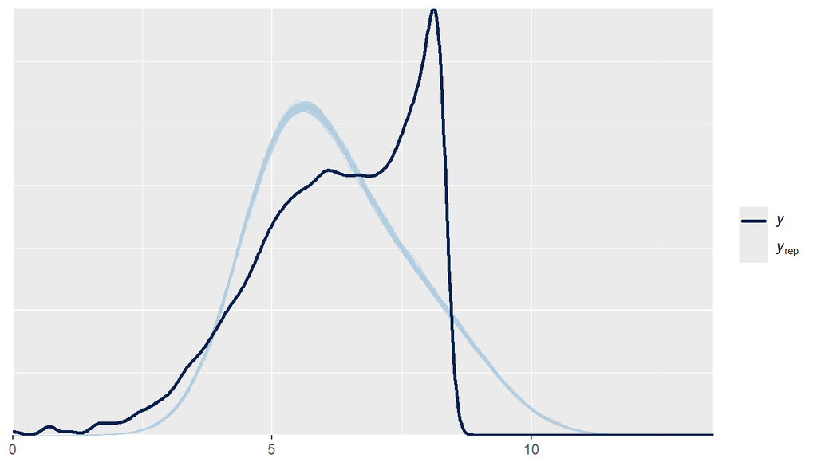

```r
pp_check(fit_hier, ndraws = 100)
```

This command compares the distribution of simulated log-energy values from the posterior predictive distribution against the observed log-energy distribution.

If the model is reasonable, the simulated distributions will broadly overlay the observed distribution. Large discrepancies (for example, the model systematically under-predicting high-energy intervals) would suggest the need for model refinement, such as adding interaction terms or considering non-Gaussian error structures.

# 5 Posterior Prediction

## 5.1 Scenario Definition

One of the advantages of a Bayesian model is that it provides a full posterior predictive distribution for future observations. To illustrate this, we consider a simple scenario:

> Predict solar energy output for a daylight interval in July under moderately strong irradiance, warm temperature, and relatively low cloud cover.

Concretely, suppose:

We translate these into standardized predictors using the means and standard deviations from our training data.

```r
mean_GHI   <- mean(solar_day$GHI)
sd_GHI     <- sd(solar_day$GHI)
mean_temp  <- mean(solar_day$temp)
sd_temp    <- sd(solar_day$temp)
mean_cloud <- mean(solar_day$clouds_all)
sd_cloud   <- sd(solar_day$clouds_all)

newdata <- tibble(
  GHI_scaled    = (800 - mean_GHI)   / sd_GHI,
  temp_scaled   = (25  - mean_temp)  / sd_temp,
  clouds_scaled = (20  - mean_cloud) / sd_cloud,
  month_factor  = factor(7, levels = levels(solar_day$month_factor))  # July
)

newdata
```

```
## # A tibble: 1 × 4
##   GHI_scaled temp_scaled clouds_scaled month_factor
##        <dbl>       <dbl>         <dbl> <fct>
## 1       12.7        1.51         -1.24 7
```

## 5.2 Posterior Predictive Distribution

We use `posterior_predict()` to generate draws from the predictive distribution of log-energy, then exponentiate to obtain predictions on the original Wh scale.

```r
set.seed(2025)
log_pred_draws <- posterior_predict(fit_hier, newdata = newdata, draws = 2000)
energy_pred_draws <- exp(log_pred_draws[, 1])

quantile(energy_pred_draws, probs = c(0.05, 0.5, 0.95))
```

```
##          5%         50%         95%
##  2523837642 10965648090 47434029887
```

We can also visualize the predictive distribution:

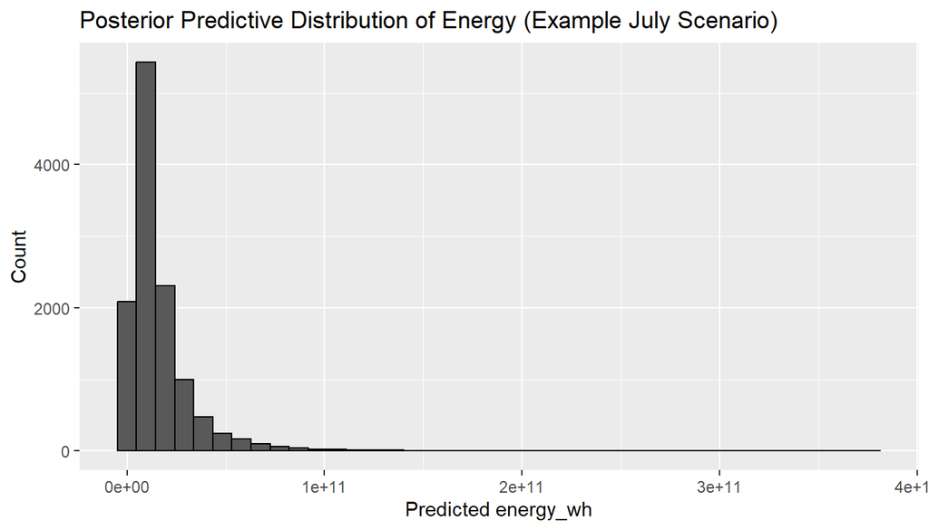

```r
pred_df <- tibble(energy = energy_pred_draws)

ggplot(pred_df, aes(x = energy)) +
  geom_histogram(bins = 40, color = "black") +
  labs(
    title = "Posterior Predictive Distribution of Energy (Example July Scenario)",
    x = "Predicted energy_wh",
    y = "Count"
  )
```

## 5.3 Interpretation for a General Audience

For this example scenario, we might summarize the result in plain language as:

# 6 Discussion and Conclusions

## 6.2 Suitability of Bayesian Methods

Overall, Bayesian methods are both appropriate and informative for this type of renewable energy modeling.

## 6.3 Limitations

Several limitations should be noted:

- Modeling only daylight intervals: We restricted the analysis to times when `isSun == 1` and both GHI and energy output are positive. This is sensible for studying the relationship between weather and active production, but it excludes transitions at dawn and dusk and does not model zero-output periods.
- Simplified functional form: The model assumes a linear relationship on the log-scale between energy and the standardized predictors. In reality, the relationship between energy and irradiance, temperature, and cloud cover may be nonlinear, and there may be important interactions (for example, temperature moderating the effect of GHI).
- Omitted variables: The dataset does not explicitly include all possible factors, such as panel tilt, shading, maintenance events, or grid curtailment. These unobserved influences are absorbed into the residual error term and may limit predictive accuracy.
- Time dependence: The model does not explicitly account for autocorrelation over time. Solar production series can exhibit temporal dependence (e.g., cloudy periods vs. clear periods) that a time-series model or Gaussian process might capture more fully.

## 6.4 Possible Extensions

Future work could extend this project in several directions:

- Nonlinear and interaction terms: Incorporating spline terms or interaction effects (for example, GHI × temperature) could provide a more flexible relationship between weather and energy.
- Time-series structure: Adding time-series components or Gaussian process priors could capture temporal dependence and improve short-term forecasting.
- More detailed hierarchy: If data from multiple sites (different solar plants or locations) were available, the model could include site-level random effects nested within regions or climatic zones.
- Mixture models: A mixture model could distinguish between different operational regimes (e.g., clear sky vs. partly cloudy, or normal operation vs. maintenance events).

Despite these limitations, the present hierarchical Bayesian model already demonstrates how modern Bayesian methods can be used to analyze renewable energy production, quantify uncertainty, and generate probabilistic forecasts that are directly useful for planning and decision-making.

# 7 References

- Gelman, A., Carlin, J. B., Stern, H. S., Dunson, D. B., Vehtari, A., & Rubin, D. B. (2013). *Bayesian Data Analysis* (3rd ed.). Chapman & Hall/CRC.
- Bürkner, P.-C. (2017). brms: An R Package for Bayesian Multilevel Models Using Stan. *Journal of Statistical Software*, 80(1), 1–28. https://doi.org/10.18637/jss.v080.i01
- R Core Team (2024). *R: A Language and Environment for Statistical Computing.* R Foundation for Statistical Computing, Vienna, Austria. https://www.R-project.org/
- Vehtari, A., Gelman, A., & Gabry, J. (2017). Practical Bayesian model evaluation using leave-one-out cross-validation and WAIC. *Statistics and Computing*, 27, 1413–1432.
- Kaggle. (2025). *Renewable Energy and Weather Conditions* [Data set]. Retrieved from https://www.kaggle.com/datasets/samanemami/renewable-energy-and-weather-conditions
- This analysis and report were partially assisted by generative AI (ChatGPT, OpenAI). All modeling decisions, interpretation, and verification were reviewed and finalized by the author.